# PA1_template.html

Abdoul Kader

12/10/2020

## Loading and preprocessing the data

### Code

```r
activity <- read.csv("activity.csv")
summary(activity)
```

```
##      steps            date              interval
##  Min.   :  0.00   Length:17568       Min.   :   0.0
##  1st Qu.:  0.00   Class :character   1st Qu.: 588.8
##  Median :  0.00   Mode  :character   Median :1177.5
##  Mean   : 37.38                      Mean   :1177.5
##  3rd Qu.: 12.00                      3rd Qu.:1766.2
##  Max.   :806.00                      Max.   :2355.0
##  NA's   :2304
```

## What is mean total number of steps taken per day?

### 1. The total number of steps taken per day

```r
activityperdate <- aggregate(data=activity, steps~date, sum, na.rm = TRUE)
head(activityperdate)
```

```
##         date steps
## 1 2012-10-02   126
## 2 2012-10-03 11352
## 3 2012-10-04 12116
## 4 2012-10-05 13294
## 5 2012-10-06 15420
## 6 2012-10-07 11015
```

### 2. Histogram of the total number of steps taken each day

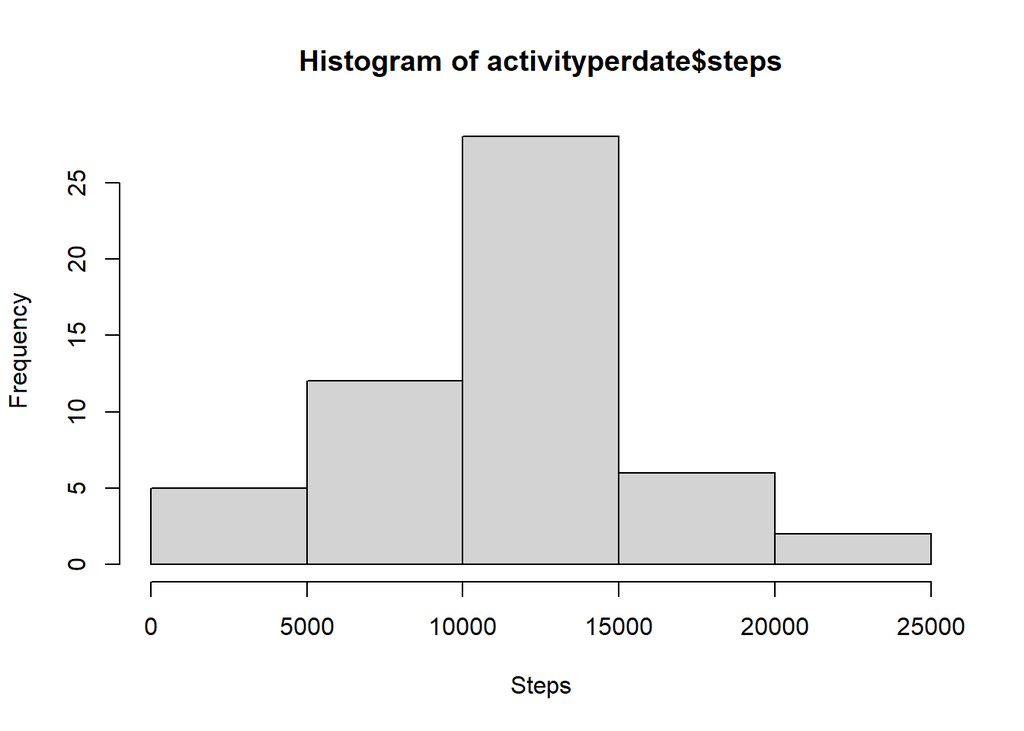

```r
hist(activityperdate$steps, xlab = "Steps")
```

### 3. Calculate and report the mean and median of the total number of steps taken per day

```r
mean(activityperdate$steps)
```

```
## [1] 10766.19
```

```r
median(activityperdate$steps)
```

```
## [1] 10765
```

## What is the average daily activity pattern?

### 1. Make a time series plot (i.e. type = “l”type = “l”) of the 5-minute interval (x-axis) and the average number of steps taken, averaged across all days (y-axis)

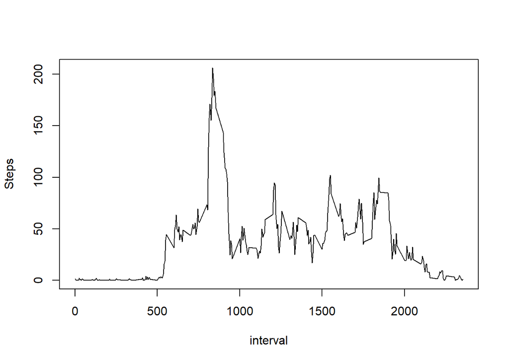

```r
interval_per_stps <- aggregate(data=activity, steps~interval, mean, na.rm=TRUE)
with(interval_per_stps, plot(interval_per_stps$interval, interval_per_stps$steps, type = "l", xlab = "interval", ylab = "Steps"))
```

### 2. Which 5-minute interval, on average across all the days in the dataset, contains the maximum number of steps?

```r
interval_per_stps$interval[which.max(interval_per_stps$steps)]
```

```
## [1] 835
```

## Imputing missing values

### 1. Calculate and report the total number of missing values in the dataset

```r
sum((is.na(activity$steps)))
```

```
## [1] 2304
```

### 2. Devise a strategy for filling in all of the missing values in the dataset

We will replace NA’s with the mean for that 5-minute interval. (Nous allons remplacer les NA avec la moyenne des intervalles 5-minute.)

### 3. New dataset that is equal to the original dataset but with the missing data filled in

```r
imputed_data <- activity
for (i in 1:length(imputed_data$steps)) {
   if (is.na(imputed_data$steps[i])) {
      imputed_data$steps[i] <- interval_per_stps$steps[interval_per_stps$interval == imputed_data$interval[i]]
   }
}
head(imputed_data)
```

```
##       steps       date interval
## 1 1.7169811 2012-10-01        0
## 2 0.3396226 2012-10-01        5
## 3 0.1320755 2012-10-01       10
## 4 0.1509434 2012-10-01       15
## 5 0.0754717 2012-10-01       20
## 6 2.0943396 2012-10-01       25
```

### 4. histogram of the total number of steps taken each day and Calculate and report the mean and median total number of steps taken per day

```r
imp_steps_per_day <- aggregate(steps ~ date, imputed_data, sum, na.rm = TRUE)
sum(is.na(imp_steps_per_day$steps))
```

```
## [1] 0
```

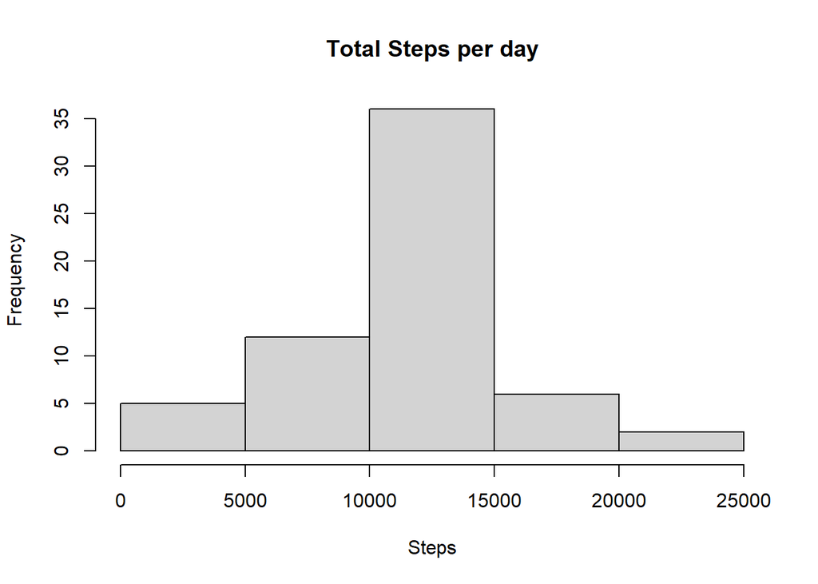

```r
hist(imp_steps_per_day$steps, main = "Total Steps per day", xlab = "Steps")
```

```r
mean(imp_steps_per_day$steps)
```

```
## [1] 10766.19
```

```r
median(imp_steps_per_day$steps)
```

```
## [1] 10766.19
```

## Are there differences in activity patterns between weekdays and weekends?

### 1. New factor variable in the dataset with two levels – “weekday” and “weekend” indicating whether a given date is a weekday or weekend day.

```r
imputed_data$date <- as.Date(imputed_data$date)
imputed_data$wkdy <- "weekday"
imputed_data$wkdy[weekdays(imputed_data$date) == "samedi" | weekdays(imputed_data$date) == "dimanche"] <- "weekend"
imputed_data$wkdy <- as.factor(imputed_data$wkdy)
```

### 2. Plot containing a time series plot

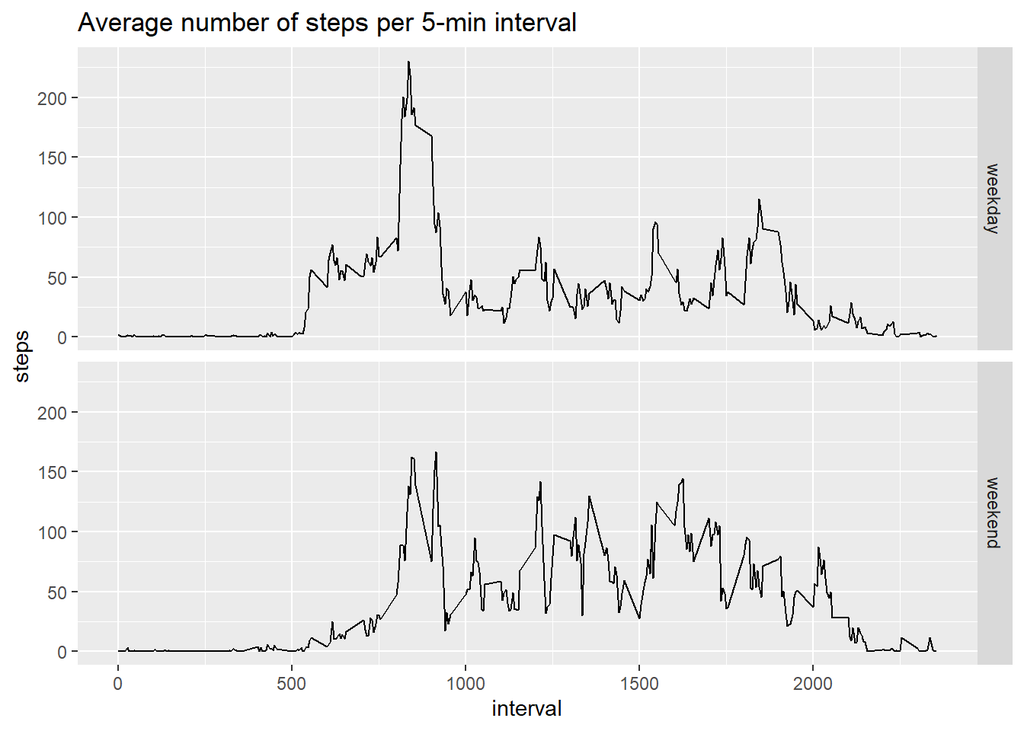

```r
imputed_data_interval <- aggregate(steps ~ interval + wkdy, imputed_data, mean, na.rm = TRUE)

library("ggplot2")
g <- ggplot(imputed_data_interval, aes(interval, steps))
g + facet_grid(wkdy ~ .) + geom_line() + ggtitle("Average number of steps per 5-min interval")
```